# BellaBeat’s Competitor’s Performance

Anorup Kanti Das

2025-08-27

## About The Analysis

This analysis explores data from Fitbit, one of Bellabeat’s key competitors in the smart device market. By examining user activity and behavior trends, we aim to uncover insights that can guide Bellabeat’s marketing efforts. Understanding how consumers engage with Fitbit devices will help us identify opportunities to better position Bellabeat and tailor our messaging to appeal to health-conscious users.

#### About The Data.

The data belongs to Fitbit Fitness Tracker data. You can download the datasets [here](https://www.kaggle.com/datasets/arashnic/fitbit). Although the data has some limitations such as not being current, the sample size being small and not gender specific. Despite these limitations, insights remain valuable for understanding general health trends. We will still work with as much data we have to analyze and derive conclusions. After that we will share recommendations to Bellabeat’s marketing team to promote their products.

## Analysis & Visualizations

#### 1. Analyze Daily Activity Trends

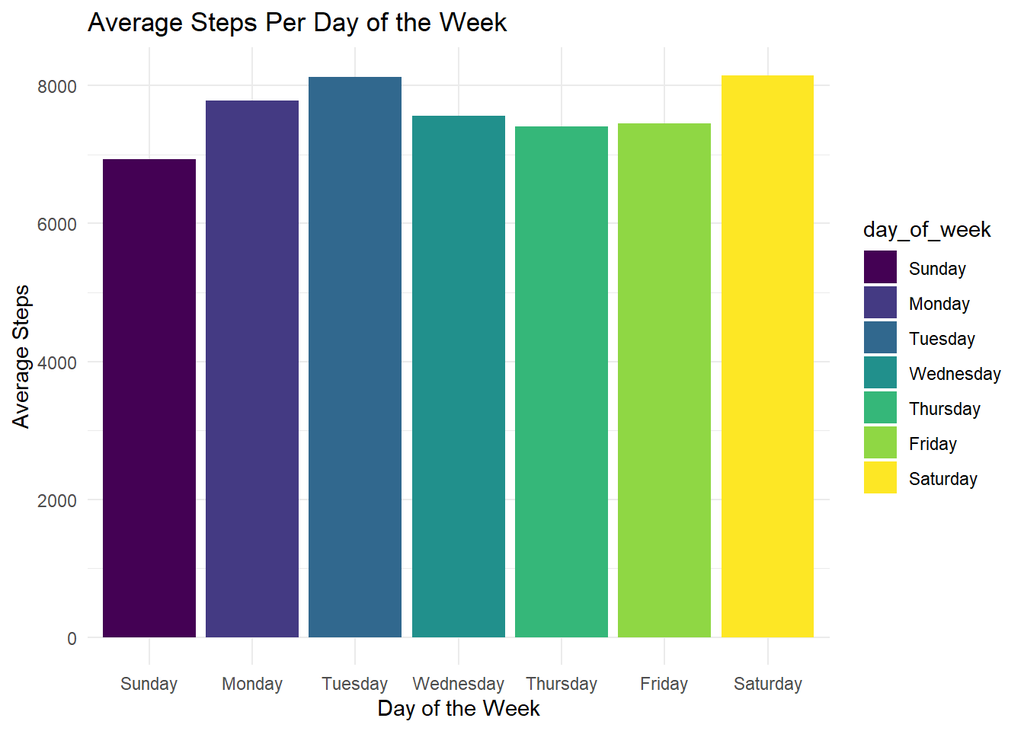

#### 2 Analyze the Relationship Between Steps and Calories

See if a person’s step count is related to the calories they burn.

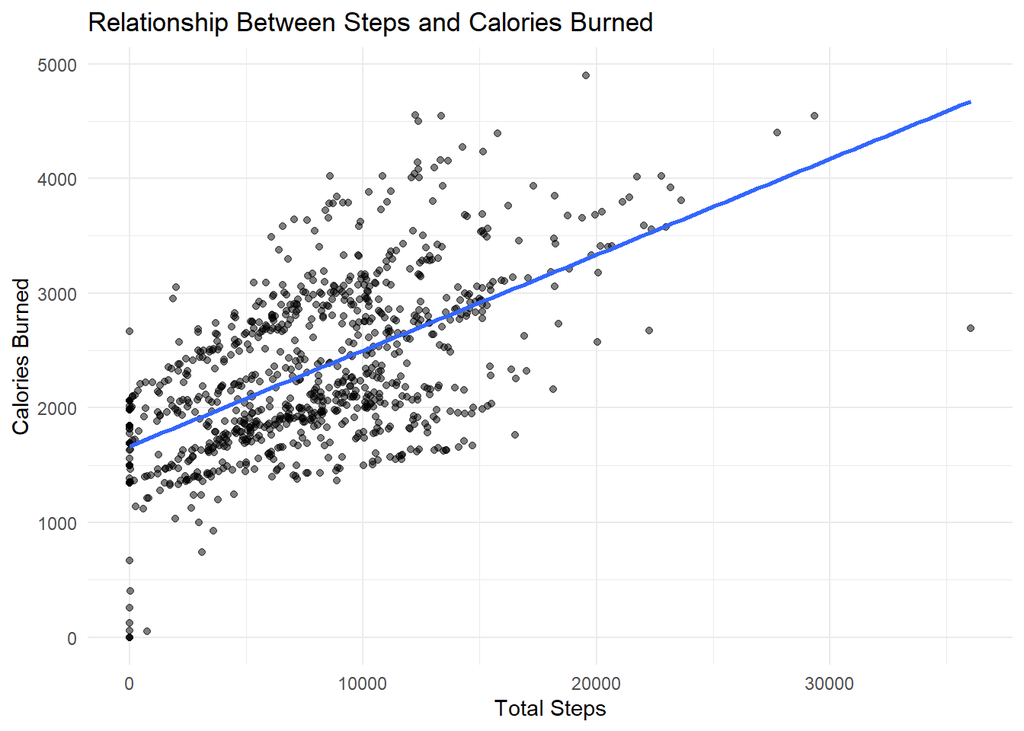

#### 3. Analyze User Sleep Habits

Look at the data to see how much users are sleeping on average.

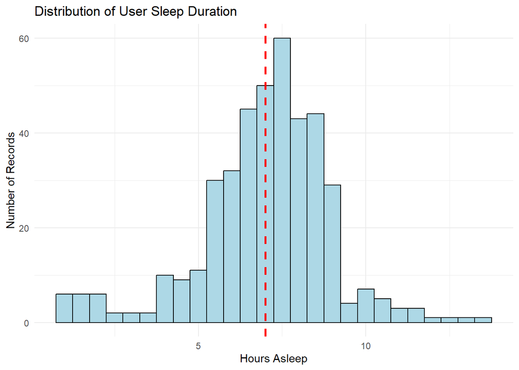

- **Insight**: The average user sleeps around 7 hours, which is a good amount. However, the histogram shows that there’s a wide range, with many users sleeping much less than the recommended 7-9 hours. This is a perfect opportunity for BellaBeat.

## Recommendations For Bellabeat

#### 2. Highlight the Importance of Sleep

- **Insight**: While users track steps, many don’t consistently track their sleep, and some get less than the recommended amount.
- **Recommendation**: Launch a campaign called “Sleep & Shine.” Focus on promoting the importance of sleep for beauty and wellness. Use the Bellabeat app to send reminders to users to wind down before bed and showcase the app’s sleep-tracking features.

#### 3. Use Gamification to Drive Engagement

- **Insight**: The most active users are consistently taking steps and burning calories.
- **Recommendation**: Bellabeat can increase engagement by creating weekly step or active minutes challenges. Reward users with virtual badges or small discounts for hitting their goals. This can motivate users to be more active and to use the product more consistently.